# Unveiling Patterns in NYC Shooting Incidents: An Analysis of Location and Time

Katrina Storey

2023-08-15

This document presents an analysis of the “NYPD Shooting Incident Data (Historic)” dataset. The dataset contains information about shooting incidents reported by the New York City Police Department over a specific period.

# Step 0: Import Libraries

In this project I will be utilizing the following libraries:

```r
library(dplyr)
library(knitr)
library(forcats)
library(lubridate)
library(ggplot2)
library(tidyverse)
library(viridis)
```

# Step 1: Import Data

## NYPD Shooting Incident Data (Historic)

This dataset is a breakdown of every shooting incident that occurred in New York City, New York going back to 2006 through the end of the previous calendar year (2022). This data is manually extracted every quarter and reviewed by the Office of Management Analysis and Planning before being posted on the NYPD website. Each record represents a shooting incident in NYC and includes information about the event, the location and time of occurrence. In addition, information related to suspect and victim demographics is also included.

```
Rows: 27,312
Columns: 21
$ INCIDENT_KEY            <int> 228798151, 137471050, 147998800, 146837977, 58921844, 219559682, 85295722, 71662474, 83002139, 86437261, 74998200, 74363835, 234756217, 78961869, 53891791, 32914993, 73879554, 87694905, …
$ OCCUR_DATE              <fct> 05/27/2021, 06/27/2014, 11/21/2015, 10/09/2015, 02/19/2009, 10/21/2020, 06/17/2012, 03/08/2010, 02/05/2012, 08/26/2012, 10/10/2010, 08/29/2010, 10/09/2021, 05/25/2011, 11/09/2008, 07/05/…
$ OCCUR_TIME              <fct> 21:30:00, 17:40:00, 03:56:00, 18:30:00, 22:58:00, 21:36:00, 22:47:00, 19:41:00, 05:45:00, 01:10:00, 03:21:00, 01:27:00, 20:17:00, 21:58:00, 20:13:00, 01:27:00, 02:22:00, 21:07:00, 02:44:…
$ BORO                    <fct> QUEENS, BRONX, QUEENS, BRONX, BRONX, BROOKLYN, QUEENS, BROOKLYN, QUEENS, QUEENS, MANHATTAN, BROOKLYN, BROOKLYN, BRONX, BROOKLYN, BRONX, MANHATTAN, BROOKLYN, BROOKLYN, BROOKLYN, MANHATTAN…
$ LOC_OF_OCCUR_DESC       <fct> , , , , , , , , , , , , , , , , , , , , , , , , , , , , , , , , , , , , , , , , , , , , , , , , , , , , , , , , , , , , , , , , , , , , , , , ,
$ PRECINCT                <int> 105, 40, 108, 44, 47, 81, 114, 81, 105, 101, 23, 75, 71, 50, 78, 47, 30, 81, 73, 71, 30, 84, 78, 90, 47, 105, 60, 48, 47, 106, 28, 75, 79, 78, 120, 75, 90, 73, 75, 79, 23, 73, 73, 75, 75…
$ JURISDICTION_CODE       <int> 0, 0, 0, 0, 0, 0, 0, 0, 0, 0, 2, 0, 0, 0, 2, 2, 0, 0, 0, 0, 0, 0, 0, 0, 0, 0, 2, 0, 0, 0, 0, 2, 0, 0, 0, 0, 0, 0, 0, 0, 2, 0, 0, 0, 0, 0, 0, 0, 2, 0, 2, 0, 0, 2, 2, 0, 0, 0, 0, 0, 0, 2, …
$ LOC_CLASSFCTN_DESC      <fct> , , , , , , , , , , , , , , , , , , , , , , , , , , , , , , , , , , , , , , , , , , , , , , , , , , , , , , , , , , , , , , , , , , , , , , , ,
$ LOCATION_DESC           <fct> , , , , , , , , , MULTI DWELL - APT BUILD, MULTI DWELL - PUBLIC HOUS, GROCERY/BODEGA, , , MULTI DWELL - PUBLIC HOUS, MULTI DWELL - PUBLIC HOUS, , MULTI DWELL - APT BUILD, , MULTI DWELL -…
$ STATISTICAL_MURDER_FLAG <fct> false, false, true, false, true, true, false, true, false, false, false, false, false, false, false, false, true, false, false, false, true, false, false, false, false, false, true, true…
$ PERP_AGE_GROUP          <fct> , , , , 25-44, , , , , 25-44, , 25-44, , UNKNOWN, UNKNOWN, UNKNOWN, 25-44, , , 25-44, 18-24, , , UNKNOWN, 45-64, , , , 25-44, 25-44, 18-24, 25-44, UNKNOWN, 25-44, 18-24, 18-24, , 18-24, …
$ PERP_SEX                <fct> , , , , M, , , , , M, , M, , U, U, M, M, , , M, M, , , M, M, , , , F, M, M, M, M, M, M, F, , M, M, M, M, , , M, , M, , M, M, U, M, M, M, F, M, U, M, , M, , M, , M, M, M, , , M, , , M, M,
$ PERP_RACE               <fct> , , , , BLACK, , , , , BLACK, , BLACK, , UNKNOWN, UNKNOWN, UNKNOWN, BLACK, , , BLACK, BLACK, , , BLACK, BLACK, , , , BLACK HISPANIC, BLACK HISPANIC, BLACK, BLACK, BLACK, BLACK, BLACK HIS…
$ VIC_AGE_GROUP           <fct> 18-24, 18-24, 25-44, <18, 45-64, 25-44, 25-44, 18-24, 25-44, 25-44, 25-44, 25-44, 25-44, 18-24, 25-44, 18-24, 25-44, 25-44, 25-44, 25-44, 18-24, 18-24, 25-44, 45-64, 25-44, 18-24, 18-24,…
$ VIC_SEX                 <fct> M, M, M, M, M, M, M, M, M, M, M, M, M, M, M, M, M, M, M, M, F, M, M, M, M, M, M, M, M, M, M, M, M, M, M, M, M, M, M, M, M, M, M, M, M, M, M, M, M, M, M, M, M, M, M, M, F, M, M, M, M, M, …
$ VIC_RACE                <fct> BLACK, BLACK, WHITE, WHITE HISPANIC, BLACK, BLACK, BLACK, BLACK, BLACK, BLACK, BLACK, BLACK, BLACK, WHITE, BLACK HISPANIC, BLACK, BLACK, BLACK, BLACK, WHITE, BLACK, BLACK, BLACK, WHITE, …
$ X_COORD_CD              <dbl> 1058925.0, 1005028.0, 1007667.9, 1006537.4, 1024921.8, 1004234.3, 998860.0, 1002882.9, 1054366.4, 1053936.6, 999061.4, 1013136.0, 996148.0, 1010353.4, 988398.4, 1026013.0, 999967.4, 1005…
$ Y_COORD_CD              <dbl> 180924.0, 234516.0, 209836.5, 244511.1, 262189.4, 186461.7, 214885.0, 192219.7, 196628.4, 157130.4, 229911.7, 179968.0, 181562.0, 261534.3, 187950.6, 261421.1, 240325.6, 186370.9, 183194…
$ Latitude                <dbl> 40.66296, 40.81035, 40.74261, 40.83778, 40.88624, 40.67846, 40.75648, 40.69426, 40.70611, 40.59770, 40.79773, 40.66061, 40.66502, 40.88449, 40.68257, 40.88412, 40.82631, 40.67820, 40.669…
$ Longitude               <dbl> -73.73084, -73.92494, -73.91549, -73.91946, -73.85291, -73.92795, -73.94727, -73.93281, -73.74711, -73.74906, -73.94651, -73.89589, -73.95711, -73.90560, -73.98504, -73.84897, -73.94321,…
$ Lon_Lat                 <fct> POINT (-73.73083868899994 40.662964620000025), POINT (-73.92494232599995 40.81035186300006), POINT (-73.91549174199997 40.74260663300004), POINT (-73.91945661499994 40.83778200300003), P…
```

# Step 2: Tidy and Transform Data

For this specific project, there are a few columns that I will not be utilizing, and I will start the data cleaning process by removing them.:

**VIC_RACE**, **VIC_SEX**, **VIC_AGE_GROUP**, **PERP_RACE**, **PERP_SEX**, **PERP_AGE_GROUP**, **JURISDICTION_CODE**, **Longitude**, **Latitude**, **X_COORD_CD**, **Y_COORD_CD**, and **Lon_Lat**.

When the dataset was imported I set the argument stringsAsFactors to TRUE, but there are a few columns we need to convert:  
**INCIDENT_KEY** needs to be a character  
**PRECINCT** needs to be a factor

```r
# Convert datatypes
# INCIDENT_KEY as a character
cleanIncidents$INCIDENT_KEY  = as.character(cleanIncidents$INCIDENT_KEY)
# PRECINCT  as a factor
cleanIncidents$PRECINCT = as.factor(cleanIncidents$PRECINCT)
```

Next we are going to check the categories in each column for errors, unknown types, and out of range data:

```r
#Check facor levels for errors

levels(cleanIncidents$BORO)
```

```
[1] "BRONX"         "BROOKLYN"      "MANHATTAN"     "QUEENS"        "STATEN ISLAND"
```

```r
levels(cleanIncidents$PRECINCT)
```

```
 [1] "1"   "5"   "6"   "7"   "9"   "10"  "13"  "14"  "17"  "18"  "19"  "20"  "22"  "23"  "24"  "25"  "26"  "28"  "30"  "32"  "33"  "34"  "40"  "41"  "42"  "43"  "44"  "45"  "46"  "47"  "48"  "49"  "50"  "52"  "60"  "61"
[37] "62"  "63"  "66"  "67"  "68"  "69"  "70"  "71"  "72"  "73"  "75"  "76"  "77"  "78"  "79"  "81"  "83"  "84"  "88"  "90"  "94"  "100" "101" "102" "103" "104" "105" "106" "107" "108" "109" "110" "111" "112" "113" "114"
[73] "115" "120" "121" "122" "123"
```

```r
levels(cleanIncidents$LOC_OF_OCCUR_DESC)
```

```
[1] ""        "INSIDE"  "OUTSIDE"
```

```r
levels(cleanIncidents$LOC_CLASSFCTN_DESC)
```

```
 [1] ""            "COMMERCIAL"  "DWELLING"    "HOUSING"     "OTHER"       "PARKING LOT" "PLAYGROUND"  "STREET"      "TRANSIT"     "VEHICLE"
```

```r
levels(cleanIncidents$LOCATION_DESC)
```

```
 [1] ""                          "(null)"                    "ATM"                       "BANK"                      "BAR/NIGHT CLUB"            "BEAUTY/NAIL SALON"         "CANDY STORE"
 [8] "CHAIN STORE"               "CHECK CASH"                "CLOTHING BOUTIQUE"         "COMMERCIAL BLDG"           "DEPT STORE"                "DOCTOR/DENTIST"            "DRUG STORE"
[15] "DRY CLEANER/LAUNDRY"       "FACTORY/WAREHOUSE"         "FAST FOOD"                 "GAS STATION"               "GROCERY/BODEGA"            "GYM/FITNESS FACILITY"      "HOSPITAL"
[22] "HOTEL/MOTEL"               "JEWELRY STORE"             "LIQUOR STORE"              "LOAN COMPANY"              "MULTI DWELL - APT BUILD"   "MULTI DWELL - PUBLIC HOUS" "NONE"
[29] "PHOTO/COPY STORE"          "PVT HOUSE"                 "RESTAURANT/DINER"          "SCHOOL"                    "SHOE STORE"                "SMALL MERCHANT"            "SOCIAL CLUB/POLICY LOCATI"
[36] "STORAGE FACILITY"          "STORE UNCLASSIFIED"        "SUPERMARKET"               "TELECOMM. STORE"           "VARIETY STORE"             "VIDEO STORE"
```

```r
levels(cleanIncidents$STATISTICAL_MURDER_FLAG)
```

```
[1] "false" "true"
```

There are three columns containing the values ““,”(null)“. For the purpose of handling missing data, I will collapse these values and assign them to the category”Unknown”:

**LOC_OF_OCCUR_DESC**, **LOC_CLASSFCTN_DESC**, **LOCATION_DESC**

```r
#Collapse "", "(null)" categories into "Unknown"
collapsedIncidents <- cleanIncidents %>%
  mutate(LOC_OF_OCCUR_DESC = fct_collapse(LOC_OF_OCCUR_DESC, Unknown = ""),
         LOC_CLASSFCTN_DESC = fct_collapse(LOC_CLASSFCTN_DESC, Unknown = ""),
         LOCATION_DESC = fct_collapse(LOCATION_DESC, Unknown = c("","(null)")))
```

**Missing Data**

There are several factors that can contribute to the presence of missing or unknown data regarding the location of shooting incidents. These factors include the unavailability or non-reporting of specific location details or classifications for certain incidents. Additionally, incomplete incident reports or limited information provided by witnesses can contribute to this issue. The collection of data can be a complex process, often constrained by time and resource limitations, which may prevent the collection of detailed information for all incidents. Consequently, some information might not be captured. It is worth noting that the data spans a period of approximately 17 years, during which data collection practices may have changed, resulting in inconsistencies in recording location or classification information.

# Step 3: Analysis: Visualizations and Modeling

## Research Questions

1. Boroughs  
   Which boroughs have the most shootings overall? Which boroughs have the most murders relatively?
2. Locations  
   How useful is the categorical location data?
3. Time and Day  
   When are shootings most likely to occur?

## Boroughs

New York City is organized into five distinct governmental districts known as boroughs, Brooklyn, Queens, Manhattan, Staten Island, and the Bronx. This form of local governance is quite exceptional, being specific to New York City and having limited counterparts on the East Coast and in Alaska. However, these counterparts do not possess the same county-like structure as the boroughs in New York City.

**Shootings by Borough**

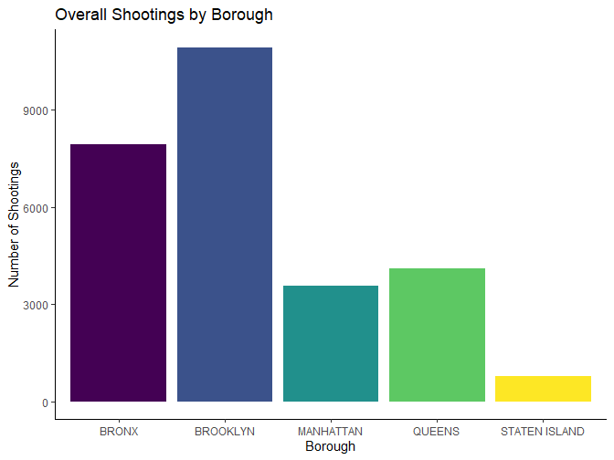

```r
#Group shootings by borough
shootings <- collapsedIncidents %>%
  group_by(BORO) %>%
  count()
#Plot data
ggplot(shootings, aes(x = BORO, y = n)) +
  geom_col(fill = viridis(5)) +
  labs(title = "Overall Shootings by Borough",
       x = "Borough",
       y = "Number of Shootings") +
  theme_classic()
```

**Relative Murders**

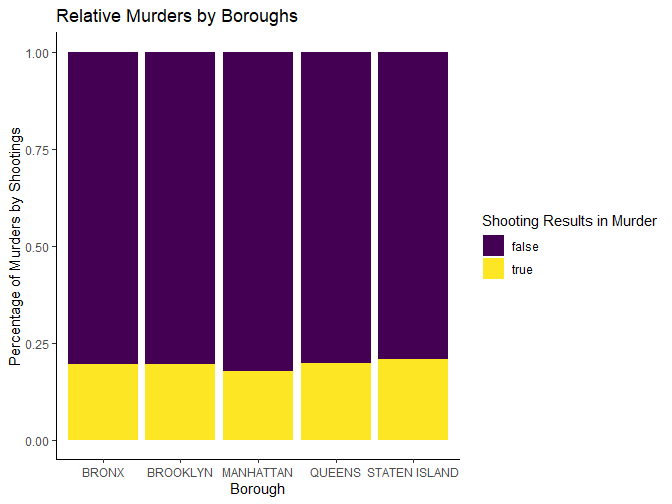

```r
# Group pecentage of shootings resulting in murder by borough
murders <- collapsedIncidents %>%
    group_by(BORO, STATISTICAL_MURDER_FLAG) %>%
    count()
# Plot data
ggplot(murders, aes(x = BORO, y = n, fill = as.factor(STATISTICAL_MURDER_FLAG))) +
  geom_col(position = "fill") +
  labs(title = "Relative Murders by Boroughs",
       x = "Borough",
       y = "Percentage of Murders by Shootings",
       fill = "Shooting Results in Murder") +
  scale_fill_viridis(discrete = TRUE) +
  theme_classic()
```

### General Observations

While analyzing the above graphs, it is apparent that certain boroughs exhibit a higher number of shootings compared to others. It is also worth noting that the number of murders resulting from these shootings generally display a proportional relationship. In instances where a borough experiences a higher murder rate, it is primarily due to a greater frequency of shootings, rather than an increased fatality rate associated with those shootings in that specific borough.

### Follow-up questions

Do certain boroughs proportionally have more shootings than the others? What would the graphs look like if we were to pair corresponding population data to it and look at the shootings per capita?

How does population density impact the social dynamics of violence, if we were to compare NYC with a less dense cities would shooting incidents be proportional?

## Location Data

There are three distinct categories of descriptive location data that haven been gathered, which hold potential in helping our understanding of the role of location in shooting confrontations, and potentially other forms of violence. Nevertheless, as demonstrated by the graphical representations below, the investigation of such patterns is solely feasible through accurate data collection methods.

**Original Data Collection**

The graph provided below illustrates the descriptive location data that has been gathered and continues to be utilized within the timeframe of this dataset. However, it is worth noting that a significant proportion of the data (approximately 58%) remains unidentified. There is an additional concern regarding the utilization of 40 categories, with the majority of them individually representing 1% or less of the total shooting incidents, or enhanced clarity, I have collapsed categories with 500 or fewer observations into the “OTHER” category.

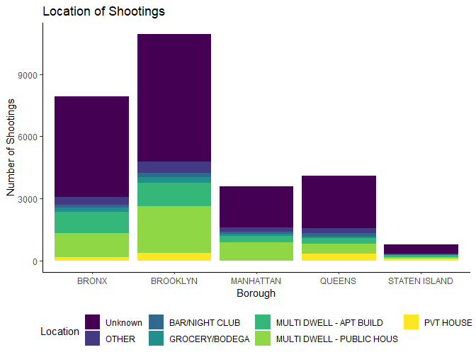

```r
#Collapse categories that have < 500 entries
other_categories <- c("ATM", "BANK", "BEAUTY/NAIL SALON", "CANDY STORE", "CHAIN STORE", "CHECK CASH", "CLOTHING BOUTIQUE", "COMMERCIAL BLDG", "DEPT STORE", "DOCTOR/DENTIST", "DRUG STORE", "DRY CLEANER/LAUNDRY", "FACTORY/WAREHOUSE", "FAST FOOD", "GAS STATION", "GYM/FITNESS FACILITY", "HOSPITAL", "HOTEL/MOTEL", "JEWELRY STORE", "LIQUOR STORE", "LOAN COMPANY", "NONE", "PHOTO/COPY STORE", "RESTAURANT/DINER", "SCHOOL", "SHOE STORE", "SMALL MERCHANT", "SOCIAL CLUB/POLICY LOCATI", "STORAGE FACILITY", "STORE UNCLASSIFIED", "SUPERMARKET", "TELECOMM. STORE", "VARIETY STORE", "VIDEO STORE")
locations <- collapsedIncidents %>%
  mutate(LOCATION_DESC = fct_collapse(LOCATION_DESC, OTHER = other_categories))

#Plot data
ggplot(locations, aes(BORO, fill = LOCATION_DESC)) +
  geom_histogram(stat = "count") +
  scale_fill_viridis(discrete = TRUE) +
  theme_classic() +
  theme(legend.position = "bottom") +
  labs(fill = "Location",
       title = "Location of Shootings",
       x = "Borough",
       y = "Number of Shootings")
```

**New Data Collection in 2022**

In the year 2022, it seems a new approach was implemented for the collection of location data. This includes two categories - one to specify whether the shooting took place indoors or outdoors, and the second using only nine general categories that can be easily understood by the data collector.

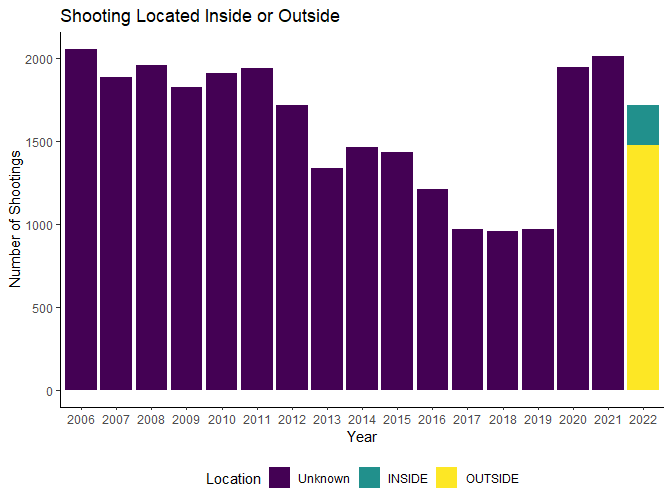

```r
#Transform Time Data
collapsedIncidents$OCCUR_YEAR = mdy(collapsedIncidents$OCCUR_DATE)
collapsedIncidents$OCCUR_YEAR = as.factor(year(collapsedIncidents$OCCUR_YEAR))

#Plot graph of LOC_OF_OCCUR_DESC
ggplot(collapsedIncidents, aes(OCCUR_YEAR, fill = LOC_OF_OCCUR_DESC)) +
  geom_histogram(stat = "count") +
  scale_fill_viridis(discrete = TRUE) +
  theme_classic() +
   theme(legend.position = "bottom") +
  labs(fill = "Location",
       title = "Shooting Located Inside or Outside",
       x = "Year",
       y = "Number of Shootings")
```

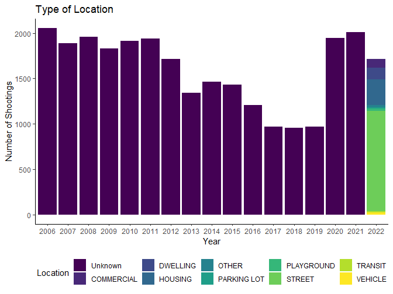

```r
#Plot graph of LOC_CLASSFCN_DESC
ggplot(collapsedIncidents, aes(OCCUR_YEAR, fill = LOC_CLASSFCTN_DESC)) +
  geom_histogram(stat = "count") +
  scale_fill_viridis(discrete = TRUE) +
  theme_classic() +
  theme(legend.position = "bottom") +
  labs(fill = "Location",
       title = "Type of Location",
       x = "Year",
       y = "Number of Shootings")
```

### General Observations

It is unfortunate that the previous location data was not collected with the intent of analysis. Although the GPS information is accessible, the type of location where the incident occurred may have potentially changed multiple times since then. Consequently, investigating the 15954 unknown data would require substantial effort and labor.  
Gratefully, it appears that in 2022, the implementation of the new data collection process regarding the categorization of locations has proven to be successful and comprehensive. It will be interesting to observe the insights that can be derived from such long-term data and the range of questions it can address.

### Follow-up questions

Based on the limited data provided, it is evident that the predominant location for incidents of shootings in 2022 was categorized as “street” and “outside.” Interestingly, these particular descriptors were not included in the previous location data. It leads us to contemplate whether the unspecified values in the prior dataset could potentially be vacant due to the fact that the incidents occurred outside, specifically on the street, rather than within a designated location.

Due to the broader nature of the updated categorization, can one infer that if a shooting occurs on an outdoor street, it is unlikely that the initial conflict involved any of the nearby establishments? If it cannot be inferred does this skew the location dataset?

## Time and Day Shootings are Most Likely to Occur

In addition to location, another relevant variable to consider when analyzing shooting incidents is time, more specifically the day of the week and time of day in which these incidents occur. As depicted in the graph provided, a discernible pattern becomes apparent, indicating a correlation between shooting incidents and the time of day.

```r
# Transform data
collapsedIncidents$OCCUR_DAY = mdy(collapsedIncidents$OCCUR_DATE)
collapsedIncidents$OCCUR_DAY = wday(collapsedIncidents$OCCUR_DAY, label = TRUE)
collapsedIncidents$OCCUR_HOUR = hour(hms(as.character(collapsedIncidents$OCCUR_TIME)))
daytimes = collapsedIncidents %>%
  group_by(OCCUR_DAY, OCCUR_HOUR) %>%
  count()
```

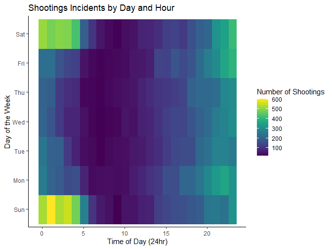

```r
# Plot data
ggplot(daytimes, aes(OCCUR_HOUR,OCCUR_DAY, fill = n)) +
   geom_raster() +
  scale_fill_viridis("Number of Shootings") +
   theme_classic() +
   labs(fill = "Shooting Incidents",
       title = "Shootings Incidents by Day and Hour",
       x = "Time of Day (24hr)",
       y = "Day of the Week")
```

### General Observations

When examining the graph provided, a noticeable trend emerges regarding the occurrence of incidents on Friday and Saturday nights, as well as the relatively safer nature of weekday mornings (and Sunday mid-mornings which may correspond with religious observations). Notably, the data indicates that the greatest likelihood of a shooting incident taking place is around 1am on Sunday mornings.

### Follow-up questions

Given that many individuals engage in recreational activities, such as the use of substances (both legal and illegal) and alcohol, during weekend nights, it is worth considering whether these behaviors may contribute to the occurrence of shooting incidents during this period?

What influence does the presence of darkness have on the frequency of shooting incidents? Does the cover of nighttime potentially embolden individuals to engage in shooting behaviors, believing they can evade detection or consequences?

# Step 4: Conclusion and Bias

## Bias

### Data Bias

When considering the various questions that can be asked with regards to a dataset, it is crucial to take into account the potential limitations and biases present. In this specific case of this dataset pertaining to shooting incidents involving victims, it is important to acknowledge the following absences:

1. Instances of shooting incidents in which the victim’s whereabouts remain unknown
- It is challenging to accurately ascertain the precise number of shootings when we solely consider the count of victims who have been located.
2. Cases where victims have been found, but it is challenging to definitively determine whether the incident involved a shooting
- In addition to the above point, it is important to consider the potential presence of an unidentified victim pool, which could potentially affect the accurate demographic profile of individuals who fall victim to shootings.
3. Victims of violent acts where firearms were not employed, such as stabbings, assaults, or battery
- We should be cautious about making generalizations about violence based solely on this dataset, as it only captures information about one specific type.
4. Limited demographic information available, encompassing solely age, race, and sex, and the absence of other demographic factors like gender identity, ethnicity, sexual orientation, religion, marital status, educational background, and employment status, also stability and transient statues.
- It is important to recognize that a comprehensive understanding of accurate victim and perpetrator profiles cannot be achieved by solely relying on three broad categories.
5. Crucially, a lack of background insights into the overall population demographics of each borough.
- Additionally, it is important to consider the broader demographic context in order to gain insights into the representation of victims and perpetrators in relation to their respective communities, and ascertain whether they originate from these regions.

### Personal Bias

I have some reservations regarding the reliability of using data for policing purposes. In the case of the NYPD, there exist four datasets consisting of historical information pertaining to police enforcement and criminal activity: Arrest, Summons, Shooting, and Complaint datasets. My concern is that these datasets are often employed to justify increased funding and the procurement of advanced weaponry, rather than being thoroughly analyzed to proactively address and prevent acts of violence particularly through community led efforts.

In this project, my bias influenced the questions I selected and the conclusions I drew. However, I made a deliberate effort to approach this dataset in a manner that sought to identify areas for enhancement. In the future if I was working with this dataset and there were particular answers being sought, I would collaborate with other data sources to mitigate any reservations I may have had.

## Conclusion

In this project, my focus was on investigating the timing and locations of shooting incidents. I conducted an examination of shootings and murders categorized by borough as well as an examination of types of location data being utilized. Moreover, I also analyzed the time of day and day of the week to determine when shootings were more likely to occur.

Examining shooting incidents by borough highlighted the importance of integrating the broader population demographics of each borough to determine whether a localized pattern exists or if it is better to explore alternative variables in the dataset. This subsequently prompted me to look at the location data within the dataset.

The location variables present in the dataset have the potential to provide valuable insights into incident hotspots and their underlying causes. However, it mostly highlights the need to follow sound data collection practices and methodology to enable effective analysis of these variables. It is commendable to the efforts made to implement a new data collection variable, enabling us to leverage this information.

One notable finding in this dataset pertains to the timing of incidents. Specifically, it was observed that a significant proportion of shooting incidents tend to transpire during the timeframe of Friday from 8pm to 5am and Saturday from 8pm to 5am. This time period represents 12% of the entire week, but it seems to be disproportionately associated with incidents of gun violence as 30% of shootings occur during this time. Consequently, dedicating attention to this aspect could potentially help to mitigate gun violence by introducing preventive measures, especially if there are discernible correlations between the violence and particular activities occurring during this period.

This dataset serves as an initial reference point focusing on the individuals involved, the timing, and the location of a specific type of violence within a highly populated urban area. However, drawing conclusive insights from this dataset alone is limited, and additional exploration of supplementary details beyond its scope is necessary.

# Resources Used

- [NYPD Shooting Incident Data (Historic) - CKAN](https://catalog.data.gov/dataset/nypd-shooting-incident-data-historic)